# Spatial proteomics with hyperLOPIT2015: from marker profiles to TAGM-MAP localisation

Shrouk Hany

# 1 Aim and background

This notebook walks through a basic spatial proteomics analysis in R, using the example `hyperLOPIT2015` dataset (mouse embryonic stem cells) from the `pRolocdata` package.

The workflow mirrors the main steps of the *Eimeria tenella* sporozoite hyperLOPIT study (Attree et al., 2026), so it can be used as training:

1. Inspect the data and the marker proteins.
2. Check that marker proteins of the same organelle have similar abundance profiles.
3. Visualise the data with PCA and t-SNE.
4. Train a **TAGM-MAP** classifier on the markers.
5. Predict the localisation of the “unknown” proteins.
6. Keep only confident predictions (localisation probability >= 0.99).
7. Compare the result with the results stored in the dataset.

The idea in one paragraph: organelles are separated on a density gradient, each gradient fraction is measured by TMT mass spectrometry, so every protein gets an abundance **profile** across fractions. Proteins in the same organelle have similar profiles. Proteins with known localisation (**markers**) are used to train a model, which then predicts the localisation of all other (**unknown**) proteins.

# 2 Installation (run once)

This chunk is **not evaluated** when knitting (`eval = FALSE`). Run it manually in the R console the first time.

```r
# BiocManager is used to install packages from Bioconductor.
if (!requireNamespace("BiocManager", quietly = TRUE)) {
  install.packages("BiocManager")
}

# pRoloc:     tools for protein subcellular localisation analysis.
# pRolocdata: example datasets, including hyperLOPIT2015.
# MSnbase:    classes and tools for storing and analysing proteomics data.
# pRolocGUI:  interactive tools for exploring spatial proteomics data.
BiocManager::install(c("pRoloc", "pRolocdata", "MSnbase", "pRolocGUI"))

# Rtsne provides the t-SNE dimensionality reduction method.
install.packages("Rtsne")
```

# 3 Load packages and data

```r
# These packages must be loaded in every new R session.
library(MSnbase)
library(pRoloc)
library(pRolocdata)

# Load the hyperLOPIT2015 dataset (an MSnSet object) from pRolocdata.
data(hyperLOPIT2015)

# Create a shorter name for convenience.
hl <- hyperLOPIT2015

sum(is.na(exprs(hl)))
```

```
## [1] 0
```

## 3.1 Overview of the object

An `MSnSet` links three tables:

- `exprs(hl)`: protein abundance in each sample (the profiles).
- `fData(hl)`: protein annotations (including the `markers` column).
- `pData(hl)`: sample annotations (replicate, TMT reagent, gradient fraction, density).

```r
# Summary: number of proteins (features), samples and annotation columns.
hl
```

```
## MSnSet (storageMode: lockedEnvironment)
## assayData: 5032 features, 20 samples
##   element names: exprs
## protocolData: none
## phenoData
##   sampleNames: X126.rep1 X127N.rep1 ... X131.rep2 (20 total)
##   varLabels: Replicate TMT.Reagent ... Iodixonal.Density (5 total)
##   varMetadata: labelDescription
## featureData
##   featureNames: Q9JHU4 Q9QXS1-3 ... Q9Z2R6 (5032 total)
##   fvarLabels: entry.name protein.description ... TAGM (26 total)
##   fvarMetadata: labelDescription
## experimentData: use 'experimentData(object)'
##   pubMedIds: 26754106
## Annotation:
## - - - Processing information - - -
## Loaded on Wed Sep 19 15:10:03 2018.
## Normalised to sum of intensities.
##  MSnbase version: 2.7.5
```

```r
# Dimensions of the quantitative data.
# Rows = protein features; columns = samples (replicates x TMT channels).
dims(hl)
```

```
##          exprs
## Features  5032
## Samples     20
```

```r
# Number of proteins in each marker class.
# "unknown" = proteins without a marker label (these are what we want to predict).
table(fData(hl)$markers)
```

```
##
##                          40S Ribosome                          60S Ribosome
##                                    27                                    43
##                    Actin cytoskeleton                               Cytosol
##                                    13                                    43
## Endoplasmic reticulum/Golgi apparatus                              Endosome
##                                   107                                    13
##                  Extracellular matrix                              Lysosome
##                                    13                                    33
##                         Mitochondrion                   Nucleus - Chromatin
##                                   383                                    64
##               Nucleus - Non-chromatin                            Peroxisome
##                                    85                                    17
##                       Plasma membrane                            Proteasome
##                                    51                                    34
##                               unknown
##                                  4106
```

Note the class imbalance: some classes (for example Mitochondrion) have many markers, while others (for example Endosome) have very few. Small classes are harder to model well.

The `hyperLOPIT2015` dataset is stored as an `MSnSet` object and contains quantitative spatial proteomics data. The dataset was normalized to the sum of intensities.

### 3.1.1 Dataset Dimensions

- **Number of proteins (features):** 5,032
- **Number of quantitative samples:** 20
- **Expression data:** `exprs`
- **Sample metadata:** `phenoData`
- **Protein metadata:** `featureData`
- **Publication PMID:** 26754106
- **MSnbase version recorded in the dataset:** 2.7.5

#### 3.1.1.1 Sample Metadata

The dataset contains 20 quantitative samples across two replicates. Sample metadata include:

- `Replicate`
- `TMT.Reagent`
- `Acquisition.Method`
- `Gradient.Fraction`
- `Iodixonal.Density`

#### 3.1.1.2 Protein Localization Labels

The protein metadata contain localization labels for 5,032 proteins. The distribution of the labels is summarized below.

| Subcellular compartment | Number of proteins |
| --- | --- |
| 40S Ribosome | 27 |
| 60S Ribosome | 43 |
| Actin cytoskeleton | 13 |
| Cytosol | 43 |
| Endoplasmic reticulum/Golgi apparatus | 107 |
| Endosome | 13 |
| Extracellular matrix | 13 |
| Lysosome | 33 |
| Mitochondrion | 383 |
| Nucleus - Chromatin | 64 |
| Nucleus - Non-chromatin | 85 |
| Peroxisome | 17 |
| Plasma membrane | 51 |
| Proteasome | 34 |
| Unknown | 4,106 |
| **Total** | **5,032** |

#### 3.1.1.3 Initial Observations

Most proteins (4,106; approximately 81.6%) are labelled `unknown`, while 926 proteins have an assigned subcellular localization label.

**Reference:** Publication associated with the dataset, PMID: [26754106](https://pubmed.ncbi.nlm.nih.gov/26754106/).

## 3.2 Sample metadata

```r
# Sample metadata: replicate number, TMT reagent, acquisition method,
# gradient fraction and iodixanol density.
# The 20 samples are 2 replicates x 10 fractions. Note that the first sample of
# each replicate is the cytosol (soluble) fraction and one is a chromatin
# fraction, so the x-axis is not a simple continuous density axis.
pData(hl)
```

|  | Replicate | TMT.Reagent | Acquisiton.Method | Gradient.Fraction | Iodixonal.Density |
| --- | --- | --- | --- | --- | --- |
| X126.rep1 | 1 | X126 | MS3 | Cytosol | 0.0 |
| X127N.rep1 | 1 | X127N | MS3 | 1 to 6 (pooled) | 6.0 |
| X127C.rep1 | 1 | X127C | MS3 | 8 to 9 (pooled) | 11.0 |
| X128N.rep1 | 1 | X128N | MS3 | 10 to 11 (pooled) | 13.3 |
| X128C.rep1 | 1 | X128C | MS3 | 12 | 14.6 |
| X129N.rep1 | 1 | X129N | MS3 | 14 | 17.4 |
| X129C.rep1 | 1 | X129C | MS3 | 16 | 20.1 |
| X130N.rep1 | 1 | X130N | MS3 | 18 | 26.8 |
| X130C.rep1 | 1 | X130C | MS3 | Chromatin | NA |
| X131.rep1 | 1 | X131 | MS3 | 19 | 34.5 |

[output cut: 10 more lines]

# 4 Marker classes and their abundance profiles

```r
# Names of the known localisation classes (the "unknown" label is excluded).
cls <- getMarkerClasses(hl, fcol = "markers")
cls
```

```
##  [1] "40S Ribosome"
##  [2] "60S Ribosome"
##  [3] "Actin cytoskeleton"
##  [4] "Cytosol"
##  [5] "Endoplasmic reticulum/Golgi apparatus"
##  [6] "Endosome"
##  [7] "Extracellular matrix"
##  [8] "Lysosome"
##  [9] "Mitochondrion"
## [10] "Nucleus - Chromatin"
## [11] "Nucleus - Non-chromatin"
## [12] "Peroxisome"
## [13] "Plasma membrane"
## [14] "Proteasome"
```

## 4.1 Mitochondrial markers

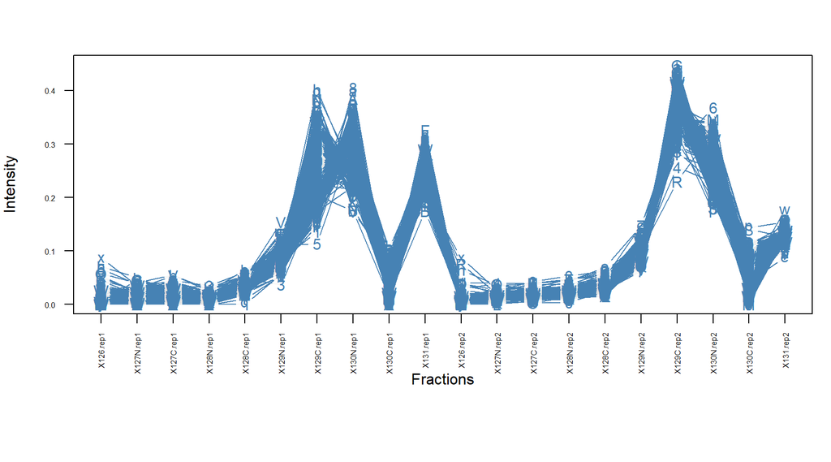

```r
# Rows of the proteins labelled as Mitochondrion.
i <- which(fData(hl)$markers == "Mitochondrion")

# Make the sample names on the x-axis readable (rotate them, add bottom margin).
# The old graphical settings are saved in `op` and restored afterwards.
op <- par(mar = c(8, 4, 3, 1), las = 2, cex.axis = 0.5)

# Each line is one protein; it shows how its abundance changes across the
# 20 samples. Markers of the same organelle should look alike.
plotDist(hl[i, ], markers = featureNames(hl)[i])
```

```r
par(op)
```

## 4.2 Lysosomal markers

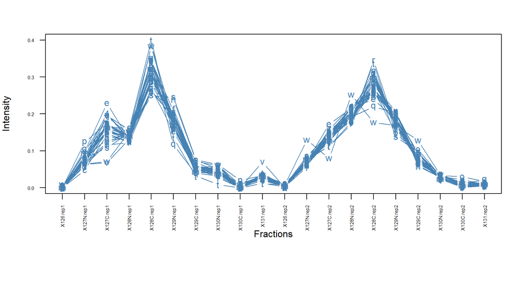

```r
# Rows of the proteins labelled as Lysosome.
j <- which(fData(hl)$markers == "Lysosome")

op <- par(mar = c(8, 4, 3, 1), las = 2, cex.axis = 0.5)

# Compare with the mitochondrial plot: the shape is consistent within the
# class but the peak is in a different place. This difference between classes
# is what allows a classifier to tell organelles apart.
plotDist(hl[j, ], markers = featureNames(hl)[j])
```

```r
par(op)
```

## 4.3 Mean profile per class

Instead of judging the plots by eye, we can compute the mean profile of every marker class and find the sample where each class peaks.

```r
# Step 1: select the proteins of one marker class.
# Step 2: take their abundance values.
# Step 3: average them for each of the 20 samples.
# Step 4: combine everything into a matrix (rows = classes, columns = samples).
mean.prof <- t(sapply(cls, function(k) {
  colMeans(exprs(hl)[which(fData(hl)$markers == k), ])
}))

# Sample with the highest mean abundance for each class.
colnames(mean.prof)[apply(mean.prof, 1, which.max)]
```

```
##  [1] "X131.rep2"  "X131.rep2"  "X127N.rep1" "X126.rep1"  "X129N.rep2"
##  [6] "X128C.rep1" "X128C.rep2" "X128C.rep1" "X129C.rep2" "X130C.rep2"
## [11] "X130C.rep1" "X130N.rep1" "X127N.rep1" "X126.rep1"
```

```r
# The same for two classes we looked at above.
names(which.max(mean.prof["Mitochondrion", ]))
```

```
## [1] "X129C.rep2"
```

```r
names(which.max(mean.prof["Lysosome", ]))
```

```
## [1] "X128C.rep1"
```

# 5 Dimensionality reduction

## 5.1 PCA

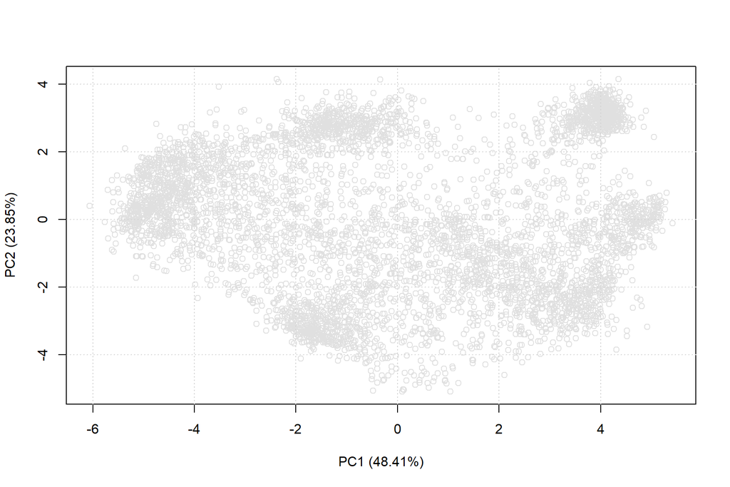

```r
# PCA reduces the profiles to a few dimensions that keep as much variation as
# possible. fcol = NULL means we do not colour by marker class yet.
# The percentages on the axes show how much variance each component explains.
plot2D(hl, fcol = NULL, method = "PCA")
```

## 5.2 t-SNE (no colours)

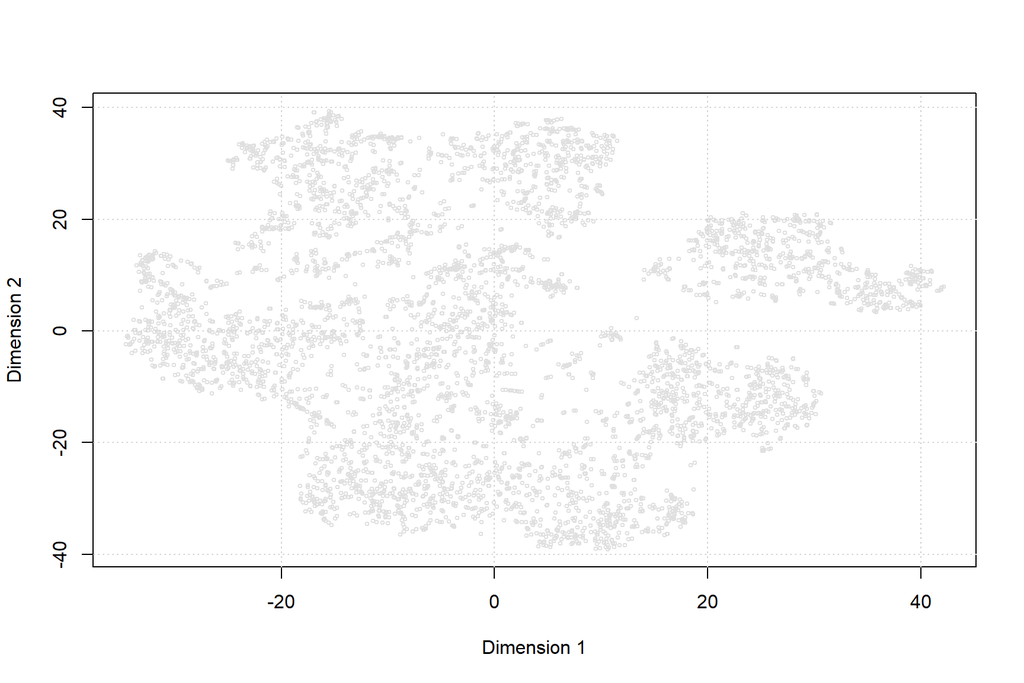

```r
# t-SNE is non-linear and tends to separate clusters more clearly than PCA.
# set.seed() makes the layout reproducible (t-SNE has a random component).
# Important: distances between clusters in t-SNE should not be over-interpreted;
# use it for exploration only.
set.seed(1)
plot2D(hl, fcol = NULL, method = "t-SNE", cex = 0.5)
```

## 5.3 t-SNE coloured by marker class

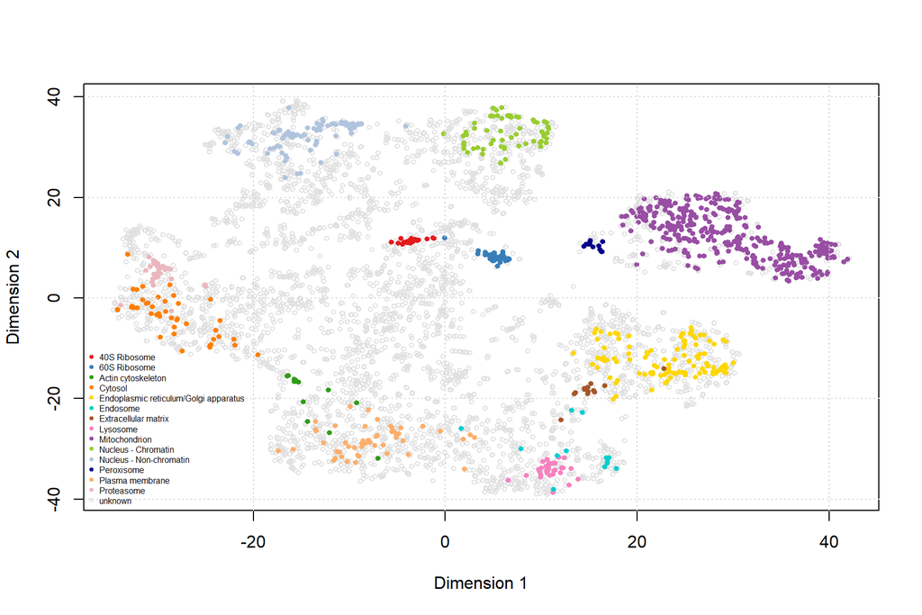

```r
# Colour proteins by their marker class. Grey points are "unknown" proteins.
# If markers of the same organelle form tight, separate groups, the experiment
# separated the organelles well. This is the equivalent of Fig. 1B in the
# Eimeria paper.
set.seed(1)
plot2D(hl, fcol = "markers", method = "t-SNE", cex = 0.6)

# Legend with the marker-class colours.
addLegend(hl, fcol = "markers", where = "bottomleft", bty = "n", cex = 0.5)
```

```r
# Save a larger version of the plot as a PNG file (the legend does not overlap
# the data as easily in a bigger figure).
png("tsne_markers.png", width = 1600, height = 1000, res = 150)
set.seed(1)
plot2D(hl, fcol = "markers", method = "t-SNE", cex = 0.6)
addLegend(hl, fcol = "markers", where = "bottomleft", bty = "n", cex = 0.6)
invisible(dev.off())
```

Observations from this plot in our run: mitochondrion, ER/Golgi, the two nuclear classes, lysosome and the ribosomes form clear groups, whereas plasma membrane, cytosol, endosome and the very small classes are more spread out or sparse. A large grey region in the middle contains many unknown proteins without markers.

# 6 TAGM-MAP classification

TAGM (T-Augmented Gaussian Mixture) is a Bayesian model. It learns the profile distribution of every marker class and also allows each protein to be an **outlier** (not belonging to any annotated class). TAGM-MAP is the fast optimisation version.

## 6.1 Train the model

```r
# The values below are the defaults of tagmMapTrain() in our pRoloc version and
# They were not tuned on this dataset.
params <- tagmMapTrain(
  hl,
  fcol    = "markers",  # column with the marker labels
  method  = "MAP",      # maximum a posteriori estimates
  numIter = 100,        # iterations of the EM algorithm
  lambda0 = 0.01,       # prior shrinkage (weak prior)
  u = 2, v = 10,        # Beta prior for the outlier proportion
  seed    = 1           # makes the result reproducible
)
params
```

```
## Object of class "MAPParams"
##  Method: MAP
```

## 6.2 Predict localisations

```r
# Predict the localisation of all proteins (markers and unknowns).
# probOutlier = TRUE also returns the probability of being an outlier.
res <- tagmMapPredict(hl, params, fcol = "markers", probOutlier = TRUE)

# If tagmMapPredict() is not found in a newer version of pRoloc, use:
# res <- tagmPredict(hl, params, fcol = "markers", probOutlier = TRUE)

# New columns added by the prediction.
fvarLabels(res)
```

```
##  [1] "entry.name"                "protein.description"
##  [3] "peptides.rep1"             "peptides.rep2"
##  [5] "psms.rep1"                 "psms.rep2"
##  [7] "phenodisco.input"          "phenodisco.output"
##  [9] "curated.phenodisco.output" "markers"
## [11] "svm.classification"        "svm.score"
## [13] "svm.top.quartile"          "final.assignment"
## [15] "first.evidence"            "curated.organelles"
## [17] "cytoskeletal.components"   "trafficking.proteins"
## [19] "protein.complexes"         "signalling.cascades"
## [21] "oct4.interactome"          "nanog.interactome"
## [23] "sox2.interactome"          "cell.surface.proteins"
## [25] "markers2015"               "TAGM"
## [27] "tagm.map.allocation"       "tagm.map.probability"
## [29] "tagm.map.outlier"
```

```r
# First proteins: the predicted class, its probability and the outlier probability.
head(fData(res)[, c("markers", "tagm.map.allocation",
                    "tagm.map.probability", "tagm.map.outlier")])
```

|  | markers | tagm.map.allocation | tagm.map.probability | tagm.map.outlier |
| --- | --- | --- | --- | --- |
| Q9JHU4 | unknown | Nucleus - Chromatin | 9.998899e-01 | 1.101488e-04 |
| Q9QXS1-3 | unknown | Plasma membrane | 3.704985e-31 | 1.000000e+00 |
| Q9ERU9 | unknown | Nucleus - Chromatin | 4.964312e-01 | 5.034716e-01 |
| P26039 | Actin cytoskeleton | Actin cytoskeleton | 1.000000e+00 | 0.000000e+00 |
| Q8BTM8 | unknown | Nucleus - Non-chromatin | 1.573614e-20 | 1.000000e+00 |
| A2ARV4 | unknown | Lysosome | 1.000000e+00 | 3.881191e-10 |

How to read these columns:

- `tagm.map.allocation`: the class the protein is closest to.
- `tagm.map.probability`: probability of that class.
- `tagm.map.outlier`: probability that the protein does not belong to any class. A protein with an outlier probability near 1 should not be trusted, even if an allocation is reported.

```r
# Sanity check: is probability + outlier close to 1 for all proteins, or only for
# the first few? In our run the median was 1 but the minimum was about 0.50.
fd <- fData(res)
summary(fd$tagm.map.probability + fd$tagm.map.outlier)
```

```
##    Min. 1st Qu.  Median    Mean 3rd Qu.    Max.
##  0.5035  1.0000  1.0000  0.9960  1.0000  1.0000
```

## 6.3 Keep only confident predictions

The Eimeria paper combines the two probabilities into one localisation probability and applies a stringent 0.99 threshold:

localisation probability = allocation probability x (1 - outlier probability)

```r
fd <- fData(res)

# Localisation probability exactly as in the paper (Methods 2.12).
fd$loc.prob <- fd$tagm.map.probability * (1 - fd$tagm.map.outlier)

# Only proteins that were "unknown" are new predictions.
unk <- fd$markers == "unknown"

# Confident new assignments.
keep <- unk & fd$loc.prob >= 0.99

sum(unk)    # unknown proteins we started with (4106 in our run)
```

```
## [1] 4106
```

```r
sum(keep)   # unknown proteins that passed the 0.99 threshold (1983 in our run)
```

```
## [1] 1983
```

```r
# Number of new assignments per organelle.
table(fd$tagm.map.allocation[keep])
```

```
##
##                          40S Ribosome                          60S Ribosome
##                                    43                                     4
##                    Actin cytoskeleton                               Cytosol
##                                     6                                   332
## Endoplasmic reticulum/Golgi apparatus                              Endosome
##                                   250                                    35
##                  Extracellular matrix                              Lysosome
##                                     2                                   252
##                         Mitochondrion                   Nucleus - Chromatin
##                                   146                                   210
##               Nucleus - Non-chromatin                            Peroxisome
##                                   364                                     9
##                       Plasma membrane                            Proteasome
##                                   321                                     9
```

Mitochondrion receives relatively few new assignments because most mitochondrial proteins are already markers. The very small classes (extracellular matrix, actin cytoskeleton, peroxisome, proteasome) also receive few assignments; with only 13 to 34 markers each, the model is expected to be more conservative for them.

#### 6.3.0.1 Prediction Summary

The TAGM-MAP model was used to predict subcellular localizations for proteins initially labelled as `unknown`, using a probability threshold of 0.99.

- **Initially unknown proteins:** 4,106
- **Proteins passing the 0.99 threshold:** 1,983
- **Percentage passing the threshold:** Approximately 48.3%

#### 6.3.0.2 Predicted Subcellular Localization Distribution

The 1,983 proteins that passed the threshold were distributed across the following subcellular compartments:

| Predicted subcellular compartment | Number of proteins |
| --- | --- |
| 40S Ribosome | 43 |
| 60S Ribosome | 4 |
| Actin cytoskeleton | 6 |
| Cytosol | 332 |
| Endoplasmic reticulum/Golgi apparatus | 250 |
| Endosome | 35 |
| Extracellular matrix | 2 |
| Lysosome | 252 |
| Mitochondrion | 146 |
| Nucleus - Chromatin | 210 |
| Nucleus - Non-chromatin | 364 |
| Peroxisome | 9 |
| Plasma membrane | 321 |
| Proteasome | 9 |

The largest predicted groups were **Nucleus - Non-chromatin (364 proteins)**, **Cytosol (332 proteins)**, and **Plasma membrane (321 proteins)**. These were followed by Lysosome (252 proteins), Endoplasmic reticulum/Golgi apparatus (250 proteins), and Nucleus - Chromatin (210 proteins).

The remaining 2,123 proteins did not pass the selected threshold. Their predicted localizations should therefore be treated as lower-confidence results under this filtering criterion, rather than as confirmed incorrect predictions.

**Note:** Passing a probability threshold of 0.99 indicates confidence according to the model’s probability measure; it does not independently confirm the biological localization of a protein.

# 7 Visualise the final assignments

```r
fd <- fData(res)

# Final label for each protein:
#   - a confident prediction (passed the 0.99 threshold), otherwise "unknown";
#   - proteins that were already markers keep their original label.
final <- ifelse(keep, fd$tagm.map.allocation, "unknown")
is.marker <- fd$markers != "unknown"
final[is.marker] <- fd$markers[is.marker]

fData(res)$final <- final
```

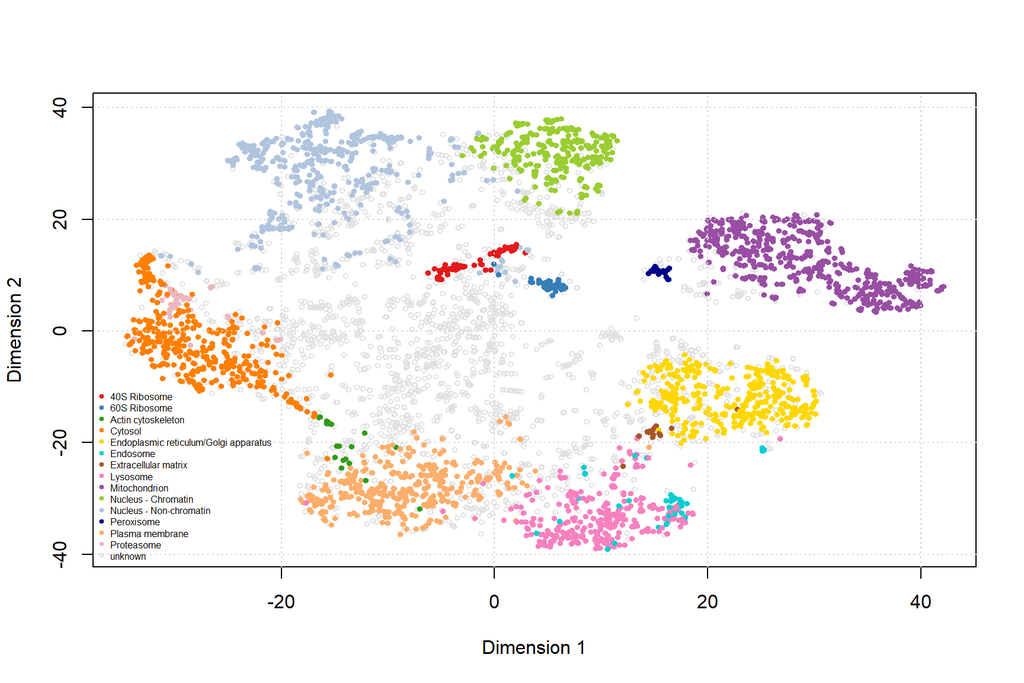

```r
# t-SNE coloured by the final assignment. Compare with the markers-only plot:
# the new assignments fill the regions around the markers, and a grey region of
# unassigned proteins remains in the centre.
set.seed(1)
plot2D(res, fcol = "final", method = "t-SNE", cex = 0.6)
addLegend(res, fcol = "final", where = "bottomleft", bty = "n", cex = 0.5)
```

```r
# Save a larger version as a PNG file.
png("tsne_final.png", width = 1800, height = 1100, res = 150)
set.seed(1)
plot2D(res, fcol = "final", method = "t-SNE", cex = 0.6)
addLegend(res, fcol = "final", where = "bottomleft", bty = "n", cex = 0.6)
invisible(dev.off())
```

The unassigned proteins (those that did not pass 0.99) may have mixed profiles, may be located in more than one compartment, or may belong to organelles without markers. The Eimeria paper reports the same kind of difficult region (HDBSCAN cluster 8, which mixes nucleus, ribosome and cytosol).

# 8 Validation against the stored results

The dataset contains a table (`TAGM`) with the results from the original study. We can use it to check that our analysis reproduces them.

```r
# Look at the stored results (MAP and MCMC versions of TAGM).
head(fData(hl)$TAGM)
```

|  | tagm.map.allocation | tagm.map.probability | tagm.mcmc.allocation | tagm.mcmc.probability | tagm.mcmc.outlier | tagm.mcmc.shannon |
| --- | --- | --- | --- | --- | --- | --- |
| Q9JHU4 | Nucleus - Chromatin | 0.999890448591981 | Nucleus - Chromatin | 1.0000000 | 0.000000000 | 2.996505e-07 |
| Q9QXS1-3 | Plasma membrane | 2.77171228994874e-31 | Plasma membrane | 0.7567776 | 1.000000000 | 2.991686e-01 |
| Q9ERU9 | Nucleus - Chromatin | 0.505396080186473 | Nucleus - Chromatin | 0.9999990 | 0.002333333 | 1.493198e-05 |
| P26039 | Actin cytoskeleton | 1 | Actin cytoskeleton | 1.0000000 | 0.000000000 | 0.000000e+00 |
| Q8BTM8 | Nucleus - Non-chromatin | 1.46640457645622e-20 | 40S Ribosome | 0.9997419 | 1.000000000 | 2.222236e-03 |
| A2ARV4 | Lysosome | 0.999999999444791 | Lysosome | 0.9999995 | 0.000000000 | 8.157766e-06 |

```r
# Stored results from the original study vs. our results.
old  <- fData(hl)$TAGM
mine <- fData(res)
colnames(old)
```

```
## [1] "tagm.map.allocation"   "tagm.map.probability"  "tagm.mcmc.allocation"
## [4] "tagm.mcmc.probability" "tagm.mcmc.outlier"     "tagm.mcmc.shannon"
```

```r
# Proteins that were unknown (the real predictions).
unk <- fData(hl)$markers == "unknown"

# 1) Do the allocations agree?
same <- as.character(old[, "tagm.map.allocation"]) ==
        as.character(mine$tagm.map.allocation)
mean(same)        # fraction of all proteins that agree (0.994 in our run)
```

```
## [1] 0.9944356
```

```r
mean(same[unk])   # fraction of unknown proteins that agree (0.993 in our run)
```

```
## [1] 0.9931807
```

```r
# 2) How similar are the probabilities?
old.p <- as.numeric(old[, "tagm.map.probability"])
cor(old.p, mine$tagm.map.probability, use = "complete.obs")   # 0.998 in our run
```

```
## [1] 0.9981726
```

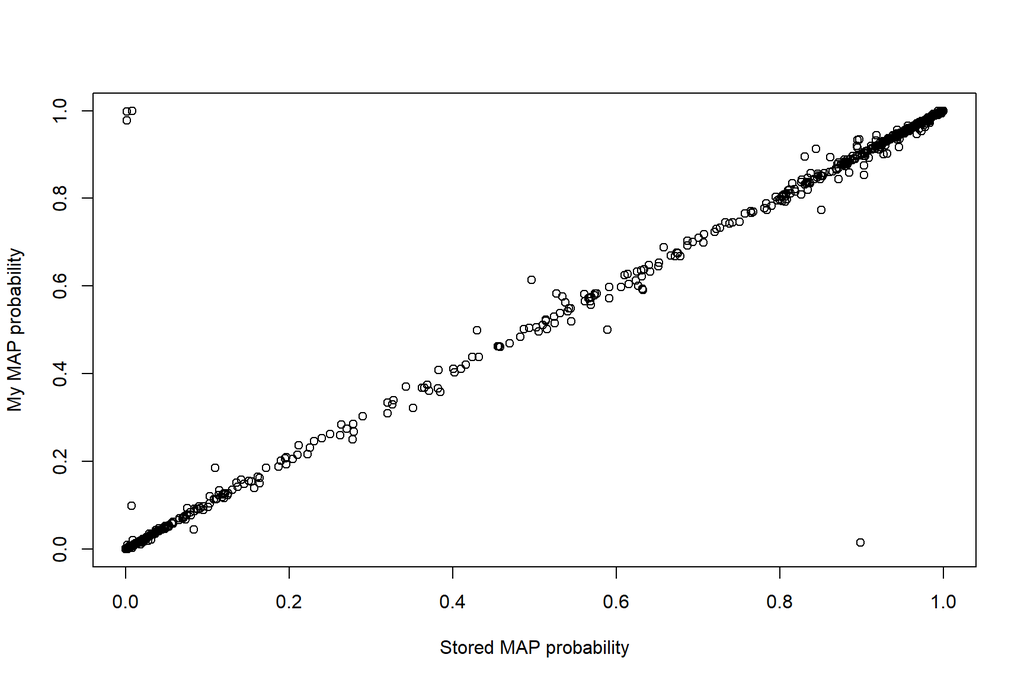

```r
plot(old.p, mine$tagm.map.probability,
     xlab = "Stored MAP probability", ylab = "My MAP probability")
```

The comparison between the stored MAP results and the newly generated predictions produced the following results:

| Evaluation metric | Result |
| --- | --- |
| Agreement in localization assignments across all proteins | 99.44% |
| Agreement in assignments among initially unknown proteins | 99.32% |
| Pearson correlation between stored and newly calculated MAP probabilities | 0.9982 |
| Number of proteins with different localization assignments | 28 |

#### 8.0.0.1 Interpretation

The newly generated TAGM-MAP predictions showed high agreement with the stored results. Approximately 99.44% of all proteins received the same localization assignment, while agreement among proteins initially labelled as `unknown` was approximately 99.32%.

The Pearson correlation coefficient of 0.9982 indicates a very strong positive linear relationship between the stored and newly calculated MAP probabilities.

Although the localization assignments differed for 28 proteins, all 28 were initially labelled as `unknown`. These differences may reflect variations in model fitting or parameter estimation and do not, by themselves, indicate which localization is biologically correct.

```r
# 3) Proteins where the two analyses disagree (28 in our run).
d <- which(!same)
length(d)
```

```
## [1] 28
```

```r
data.frame(
  stored   = old[d, "tagm.map.allocation"],
  mine     = mine$tagm.map.allocation[d],
  stored.p = old.p[d],
  my.p     = mine$tagm.map.probability[d]
)
```

| stored | mine | stored.p | my.p |
| --- | --- | --- | --- |
| Nucleus - Non-chromatin | Actin cytoskeleton | 9.539805e-32 | 5.325360e-30 |
| Nucleus - Non-chromatin | 40S Ribosome | 3.939602e-22 | 1.713770e-18 |
| Nucleus - Non-chromatin | 40S Ribosome | 2.272406e-33 | 9.488811e-33 |
| Nucleus - Non-chromatin | 40S Ribosome | 5.603925e-28 | 6.387094e-27 |
| Nucleus - Non-chromatin | 40S Ribosome | 6.946579e-03 | 9.931823e-02 |
| Proteasome | Endosome | 7.128338e-19 | 3.151217e-19 |
| Nucleus - Non-chromatin | 40S Ribosome | 2.270036e-25 | 2.843805e-25 |
| Proteasome | Endosome | 3.623461e-26 | 2.652936e-27 |
| Plasma membrane | Endosome | 1.269226e-30 | 2.274746e-30 |
| Nucleus - Non-chromatin | 40S Ribosome | 4.362480e-10 | 3.101778e-07 |

[output cut: 18 more lines]

In most of the disagreeing proteins both probabilities are extremely small, so the reported allocation is just the “least unlikely” class and a tiny numerical difference can change it. Always look at the probability, not only at the allocation.

```r
# Do any of the disagreeing proteins pass the 0.99 threshold in our results?
# If not (expected: 0), the final confident list is not affected by them.
loc.prob <- mine$tagm.map.probability * (1 - mine$tagm.map.outlier)
sum(loc.prob[d] >= 0.99)
```

```
## [1] 0
```

```r
max(loc.prob[d])   # highest localisation probability among the disagreeing proteins
```

```
## [1] 0.5229797
```

# 9 Unsupervised check with HDBSCAN

So far, the marker classes were used to train the classifier. As an independent check, we cluster the proteins **without using the markers at all** and then ask whether the clusters agree with the marker classes. This is the same idea as Fig. 1A and Table 2 in the *Eimeria* paper.

HDBSCAN is a density-based clustering method. It finds groups of proteins that lie close together and labels isolated proteins as **noise** (cluster 0).

## 9.1 Choosing minPts

`minPts` is the minimum number of proteins needed to form a cluster. The *Eimeria* paper used 12 on 1,489 proteins. Our dataset has 5,032 proteins, so we compare several values on the same t-SNE embedding before choosing one.

```r
# dbscan provides hdbscan(); Rtsne provides the t-SNE embedding.
library(dbscan)
library(Rtsne)

# 2D t-SNE embedding of the abundance profiles (perplexity 30, as in the paper).
# The same embedding is used for every minPts value below.
set.seed(1)
ts <- Rtsne(exprs(hl), perplexity = 30, check_duplicates = FALSE)$Y
```

```r
# Run HDBSCAN with several minPts values and summarise each run.
minpts.values <- c(12, 20, 30, 50)

comparison <- do.call(rbind, lapply(minpts.values, function(m) {
  hh <- hdbscan(ts, minPts = m)
  data.frame(
    minPts     = m,
    clusters   = length(setdiff(unique(hh$cluster), 0)),   # cluster 0 = noise
    noise      = sum(hh$cluster == 0),
    noise.pct  = round(100 * mean(hh$cluster == 0), 1),
    # Size of the largest cluster (how much of the data is lumped together)
    largest    = max(table(hh$cluster[hh$cluster != 0]))
  )
}))
comparison
```

| minPts | clusters | noise | noise.pct | largest |
| --- | --- | --- | --- | --- |
| 12 | 70 | 1801 | 35.8 | 565 |
| 20 | 4 | 85 | 1.7 | 4363 |
| 30 | 6 | 580 | 11.5 | 2369 |
| 50 | 5 | 700 | 13.9 | 2305 |

Results in our run:

| minPts | Clusters | Noise proteins | Observation |
| --- | --- | --- | --- |
| 12 | 70 | 1801 | Very fragmented: many small clusters, hard to interpret. Ribosomal subunits (40S, 60S) and proteasome were split from other classes. |
| 20 | 4 | 85 | Only mitochondrion and peroxisome were separated; everything else formed one large cluster. |
| **30** | **6** | **580** | Clearest split: mitochondrion/peroxisome, ER-Golgi/ECM, two nuclear clusters, one large mixed cluster and one small cluster without markers. |
| 50 | 5 | 700 | Similar to 30, but 16 of the 17 peroxisome markers became noise. |

We use **minPts = 30** for the rest of this section. The choice is a compromise between over-splitting (12) and under-splitting (20). It was made by inspecting these results, not by an objective criterion, so it should be treated as an exploratory setting. The peroxisome illustrates how sensitive small classes are: it forms its own cluster at 12 and 20, merges with the mitochondrion at 30, and is lost as noise at 50.

## 9.2 Clustering with the chosen value

```r
# Cluster the t-SNE coordinates with minPts = 30.
h <- hdbscan(ts, minPts = 30)

# Cluster sizes (0 = noise).
table(h$cluster)
```

```
##
##    0    1    2    3    4    5    6
##  580  622  532 2369  571  304   54
```

```r
# Store the cluster labels as text.
fData(hl)$hdb <- ifelse(h$cluster == 0, "noise", paste0("cluster", h$cluster))
```

```r
# Rows = known marker classes, columns = HDBSCAN clusters.
# If the experiment separated the organelles well, each class should fall
# (almost) entirely into one cluster.
table(fData(hl)$markers, fData(hl)$hdb)
```

```
##
##                                         cluster1 cluster2 cluster3 cluster4
##   40S Ribosome                                 0        0       27        0
##   60S Ribosome                                 0        0       43        0
##   Actin cytoskeleton                           0        0       13        0
##   Cytosol                                      0        0       41        0
##   Endoplasmic reticulum/Golgi apparatus        0      106        0        0
##   Endosome                                     0        2       11        0
##   Extracellular matrix                         0       13        0        0
##   Lysosome                                     0        0       33        0
##   Mitochondrion                              382        0        0        0
##   Nucleus - Chromatin                          0        0        0        0
##   Nucleus - Non-chromatin                      0        0        0       82
##   Peroxisome                                  17        0        0        0
##   Plasma membrane                              0        0       51        0
##   Proteasome                                   0        0       34        0
##   unknown                                    223      411     2116      489
##
##                                         cluster5 cluster6 noise
##   40S Ribosome                                 0        0     0
##   60S Ribosome                                 0        0     0
##   Actin cytoskeleton                           0        0     0
##   Cytosol                                      0        0     2
##   Endoplasmic reticulum/Golgi apparatus        0        0     1
##   Endosome                                     0        0     0
##   Extracellular matrix                         0        0     0
##   Lysosome                                     0        0     0
##   Mitochondrion                                0        0     1
##   Nucleus - Chromatin                         63        0     1
##   Nucleus - Non-chromatin                      0        0     3
##   Peroxisome                                   0        0     0
##   Plasma membrane                              0        0     0
##   Proteasome                                   0        0     0
##   unknown                                    241       54   572
```

Rows are the known marker classes, columns are the HDBSCAN clusters, and “unknown” are proteins without a marker label. The table is summarised below.

| Cluster | Proteins | Markers | Marker classes inside | Interpretation |
| --- | --- | --- | --- | --- |
| 1 | 622 | 399 | Mitochondrion (382), Peroxisome (17) | Mitochondrial cluster |
| 2 | 532 | 121 | ER/Golgi (106), Extracellular matrix (13), Endosome (2) | ER/Golgi cluster |
| 3 | 2,369 | 253 | 40S ribosome (27), 60S ribosome (43), Cytosol (41), Lysosome (33), Plasma membrane (51), Proteasome (34), Actin (13), Endosome (11) | Large mixed cluster |
| 4 | 571 | 82 | Nucleus - Non-chromatin (82) | Non-chromatin nuclear cluster |
| 5 | 304 | 63 | Nucleus - Chromatin (63) | Chromatin cluster |
| 6 | 54 | 0 | none | Small cluster without markers |
| noise | 580 | 8 | 1 to 3 markers from several classes | Unclustered proteins |

**What the table shows**

- **Clusters made only of markers from one organelle.** Clusters 4 and 5 each contain markers of a single class (non-chromatin and chromatin nucleus). The two nuclear compartments are clearly separated from each other.
- **Mitochondrion is almost entirely in one cluster.** 382 of 383 mitochondrial markers are in cluster 1 and 1 is in the noise. HDBSCAN found them without being given any labels, so the mitochondrial markers have consistent profiles.
- **Very few markers are lost.** Only 8 of 926 markers (less than 1%) fall into the noise, and no marker class is split across several clusters, apart from a small number of endosome markers (2 in cluster 2, 11 in cluster 3).
- **Peroxisome shares a cluster with mitochondrion.** All 17 peroxisome markers are in cluster 1. This reflects how close the two groups are in the t-SNE map at this setting, not that their profiles are identical. In our tests the peroxisome formed its own cluster at minPts = 12 and 20, and was lost as noise at minPts = 50.
- **Extracellular matrix groups with ER/Golgi** (13 markers in cluster 2). With only 13 markers, this class is very small, so we do not draw conclusions about it.
- **Cluster 3 is the limit of the method.** It contains markers from eight different classes (both ribosomal subunits, cytosol, lysosome, plasma membrane, proteasome, actin and endosome). Density alone could not separate them. This is the same kind of mixed cluster described in the *Eimeria* paper (cluster 8: nucleus, ribosome and cytosol).
- **Cluster 6 has no markers.** It contains 54 unknown proteins. It could be a sub-compartment or a group of proteins without markers in the dataset, but we did not investigate it, so we make no claim about it.

**What the table does not show**

- The 2,116 unknown proteins in cluster 3 cannot be assigned to an organelle from the clusters alone. This is why a supervised classifier (TAGM-MAP) is needed.
- The unknown proteins in clusters 1, 2, 4 and 5 are likely to be related to the markers of those clusters, but this is only a hypothesis. The clusters are not final assignments and should be compared with the TAGM-MAP results.
- The clusters come from a t-SNE embedding that changes with the seed and the perplexity, so the exact numbers may vary slightly between runs.

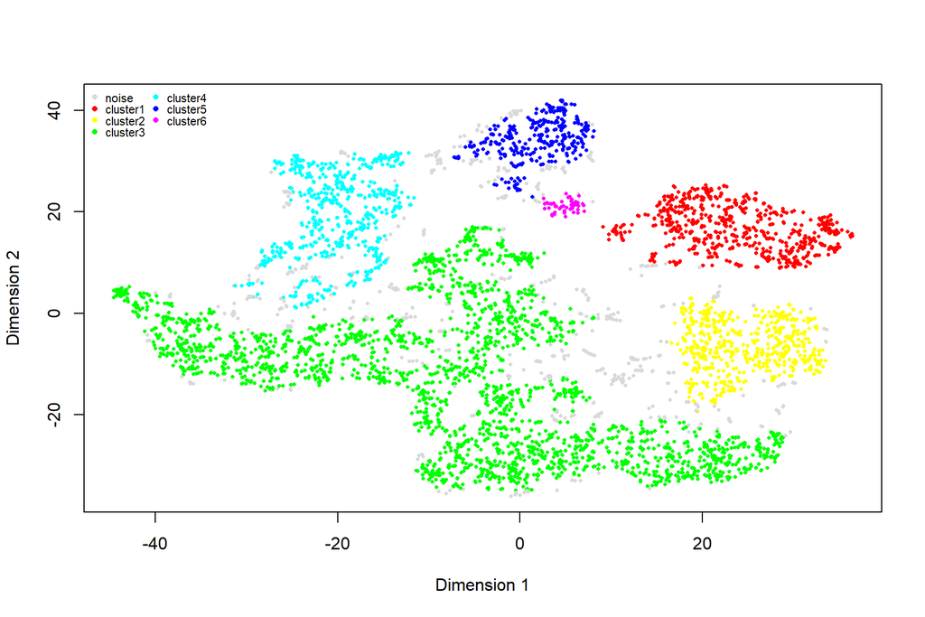

```r
# Colour the t-SNE embedding by HDBSCAN cluster (grey = noise).
pal <- c("grey85", rainbow(max(h$cluster)))
plot(ts, col = pal[h$cluster + 1], pch = 16, cex = 0.5,
     xlab = "Dimension 1", ylab = "Dimension 2")
legend("topleft",
       legend = c("noise", paste0("cluster", seq_len(max(h$cluster)))),
       col = pal, pch = 16, cex = 0.7, bty = "n",
       y.intersp = 0.8, ncol = 2)   # tighter spacing, two columns
```

**Results in our run (minPts = 30):** HDBSCAN found 6 clusters and 580 noise proteins.

- Mitochondrion markers (382 of 383) fell into a single cluster, together with the peroxisome markers.
- ER/Golgi and extracellular matrix markers formed one cluster.
- The two nuclear classes (chromatin and non-chromatin) formed two separate clusters.
- Ribosomes, cytosol, lysosome, plasma membrane, proteasome, actin and endosome markers were grouped together in one large cluster, meaning that density alone could not separate these organelles. The *Eimeria* paper describes the same kind of mixed cluster (cluster 8: nucleus, ribosome and cytosol).
- One small cluster contained no markers. We did not investigate it further.

**Caution:** the clusters depend on `minPts` and on the t-SNE layout, which changes with the seed and the perplexity. They should be used for exploration, not as final assignments.

# 10 GO enrichment of the new assignments

To check whether the confident TAGM-MAP assignments make biological sense, we tested each predicted organelle group for enriched Gene Ontology (GO) terms. Only the **new** assignments (unknown -> assigned) were tested, so the markers do not dominate the result. The background (universe) is all detected proteins, and p-values are corrected with the Benjamini-Hochberg method.

```r
# Run once
BiocManager::install(c("clusterProfiler", "org.Mm.eg.db", "enrichplot"))
```

```r
library(clusterProfiler)
library(org.Mm.eg.db)
library(enrichplot)
library(ggplot2)

# Protein IDs are UniProt accessions; remove isoform suffixes (e.g. Q9QXS1-3)
# so that the IDs can be mapped to GO annotations.
ids <- sub("-\\d+$", "", featureNames(res))

# Background = all proteins detected in the experiment.
universe <- unique(ids)

# New confident assignments, split by predicted organelle.
conf   <- fData(res)$markers == "unknown" & fData(res)$final != "unknown"
groups <- split(ids[conf], fData(res)$final[conf])

# Keep groups with at least 10 proteins (smaller groups give unstable results).
groups <- groups[sapply(groups, length) >= 10]
sapply(groups, length)
```

```
##                          40S Ribosome                               Cytosol
##                                    43                                   332
## Endoplasmic reticulum/Golgi apparatus                              Endosome
##                                   250                                    35
##                              Lysosome                         Mitochondrion
##                                   252                                   146
##                   Nucleus - Chromatin               Nucleus - Non-chromatin
##                                   210                                   364
##                       Plasma membrane
##                                   321
```

```r
# One function for the three GO ontologies:
#   CC = cellular component, MF = molecular function, BP = biological process
run_go <- function(ont) {
  compareCluster(
    geneClusters  = groups,
    fun           = "enrichGO",
    OrgDb         = org.Mm.eg.db,
    keyType       = "UNIPROT",
    ont           = ont,
    universe      = universe,
    pAdjustMethod = "BH",
    pvalueCutoff  = 0.05,
    qvalueCutoff  = 0.05
  )
}

ego.cc <- run_go("CC")
ego.mf <- run_go("MF")
ego.bp <- run_go("BP")
```

```r
# Convert GO enrichment results to data frames
cc_df <- as.data.frame(ego.cc)
mf_df <- as.data.frame(ego.mf)
bp_df <- as.data.frame(ego.bp)

# Save each ontology result as a CSV file
write.csv(cc_df, "GO_CC_results.csv", row.names = FALSE)
write.csv(mf_df, "GO_MF_results.csv", row.names = FALSE)
write.csv(bp_df, "GO_BP_results.csv", row.names = FALSE)
```

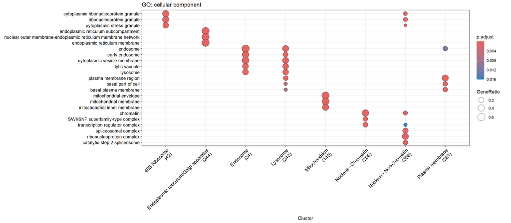

```r
# Top 3 terms per predicted organelle. Group names on the x-axis are rotated
# because they are long and overlap otherwise.
plot_go <- function(ego, title) {
  dotplot(ego, showCategory = 3, font.size = 11, label_format = 100) +
    ggtitle(title) +
    theme(
      axis.text.x  = element_text(angle = 45, hjust = 1),
      axis.text.y  = element_text(size = 10, lineheight = 0.8),   # tighter lines inside a wrapped label
      plot.margin  = margin(5, 20, 5, 10)
    )
}
plot_go(ego.cc, "GO: cellular component")
```

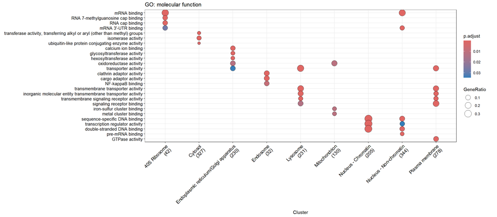

```r
plot_go(ego.mf, "GO: molecular function")
```

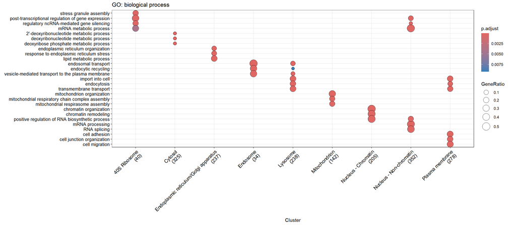

```r
plot_go(ego.bp, "GO: biological process")
```

```r
# Save each plot as its own file (use a different file name for each one!)
# Save each GO plot as a high-resolution PNG file
plots <- list(
  cc = plot_go(ego.cc, "GO: cellular component"),
  mf = plot_go(ego.mf, "GO: molecular function"),
  bp = plot_go(ego.bp, "GO: biological process")
)

for (nm in names(plots)) {
  ggsave(
    filename = paste0("go_", nm, "_dotplot.png"),
    plot = plots[[nm]],
    width = 16,
    height = 7,
    units = "in",
    dpi = 200,
    bg = "white"
  )
}
```

## 10.1 Results

**Cellular component (sanity check).** The enriched terms matched the predicted organelle in every group shown: ER membrane terms for ER/Golgi, mitochondrial envelope and inner membrane for mitochondrion, chromatin and SWI/SNF complex for the chromatin group, spliceosomal complex for the non-chromatin nuclear group, and basal plasma membrane terms for plasma membrane. The cytosol group did not show significant cellular component terms.

**Molecular function and biological process.** These describe what the proteins do, and they were also consistent with the predicted organelle:

- **Mitochondrion:** iron-sulfur cluster binding and oxidoreductase activity; mitochondrial respiratory chain complex assembly.
- **Nucleus - Chromatin:** sequence-specific DNA binding and transcription regulator activity; chromatin organization and remodeling.
- **Nucleus - Non-chromatin:** mRNA and pre-mRNA binding; RNA splicing and mRNA processing.
- **ER/Golgi:** glycosyltransferase activity; ER organization, response to ER stress and lipid metabolism.
- **Endosome:** clathrin and cargo adaptor activity; endosomal transport and endocytic recycling.
- **Lysosome and plasma membrane:** transmembrane transporter and signaling receptor activity; endocytosis and transmembrane transport. The plasma membrane group was also enriched for cell adhesion, cell junction organization and cell migration.
- **40S ribosome:** mRNA and RNA cap binding; stress granule assembly and post-transcriptional regulation of gene expression. These proteins are mostly RNA-binding proteins found with ribosomes, not ribosomal proteins themselves. This is our interpretation: the core ribosomal proteins were already markers, so they were not part of the tested group.
- **Cytosol:** only weak terms (for example deoxyribonucleotide metabolic process). This is expected for a large and heterogeneous class.

**Observations**

- Endosome and lysosome shared several terms, and lysosome and plasma membrane shared endocytosis and transport terms. This agrees with their overlap in the t-SNE map and in the HDBSCAN clusters.
- Groups with fewer than 10 new assignments (60S ribosome, actin cytoskeleton, extracellular matrix, peroxisome and proteasome) were not tested.

**Cautions**

- Cellular component terms are partly derived from earlier localisation studies, so they support the plausibility of the assignments but are not independent evidence. Molecular function and biological process terms are more informative.
- GO annotation is biased toward well-studied proteins, and each ontology only includes proteins that have an annotation in it, so group sizes differ between the three plots.
- Only the confident assignments (localisation probability >= 0.99) were tested, so the result depends on that threshold.